# Stat380 Mini-Project 2

Ben Rishel and Alven Huang

November 15, 2025

## Discussion of Group Member Contributions

The work was divided evenly between us. We contributed via a Github repository. After the work was completed, each of us reviewed the full document before submission to ensure consistency. Ben completed Tasks 1, 4, and 5. Alven completed Tasks 2 and 3.

## Front Matter

```r
rm(list = ls())
library(tidyverse)
library(readxl)
library(kableExtra)
library(forcats)

cod <- read_excel("CODGames2_mp.xlsx",
  col_types = c("text", "text", "text",
  "text", "date", "text", "text", "numeric",
  "numeric", "numeric", "numeric",
  "numeric", "text", "text", "text",
  "text", "numeric", "numeric", "numeric",
  "numeric", "numeric", "numeric",
  "numeric", "numeric", "numeric",
  "numeric", "numeric"))
```

## Task 1 - Why you should avoid using na.omit()

Let’s investigate why it is a bad idea to use na.omit() to remove observations with missing data for this dataset. First, let’s look at how many NA values we have per column through the use of an anonymous function.

```r
sapply(cod, function(x) sum(is.na(x)))
```

```
##           Map1           Map2         Choice        MapVote           Date
##             43             43              1             43              0
##    FullPartial         Result   Eliminations         Deaths          Score
##              0              0              0              0              0
##         Damage        TotalXP  PrimaryWeapon         XPType  DidPlayerVote
##              0              0              0              0              0
##       GameType       Confirms         Denies     Objectives ObjectiveKills
##              0            208            208            205            200
##       Captures       Diffuses         Plants      Detonates       Deposits
##            208            211            211            211            211
##       Time_Sec       Time_Min
##            203            203
```

If we used na.omit() on this dataset, we would remove any row that has at least one NA value. In this instance, that would result in the entire dataset being removed because there are 211 observations in the dataset and also 211 NA values for diffuses, plants, detonates, and deposits. A better approach in this instance would be to remove just the columns with so many NA values. Now, let’s confirm that there are NA values in every row.

```r
apply(cod, 1, function(x) sum(is.na(x)))
```

```
##   [1] 11 11 14 11 11 11 14 11 11  8  8 11 11 11 11 11  8 11  8  8 11 14 14 11 11
##  [26] 14 11 11 11 11 11 11 11  8  8  8 11 11 11 11 11 14 11 11 11 11 11 11 11 14
##  [51] 11 11 11 11 11 14 11 11 14 11 14 11 11 11 11 11 14 11 11 11 14 11 11 11 11
##  [76] 11 11 11 14 11 11 11 11 11 14 14 11 11 11 11 11 11 11 11 11 11 11 11 14 11
## [101] 11 11 11 11 11 11 11 11 14 11 11 11 11 11 11 11 11 11 14 11 11 11 14 11 11
## [126] 11 11 11 11 14 11 14 11 11 14 11 11 11 11 11 11 11 11 11 11 14 11 11 14 11
## [151] 11 11 14 11 14 11 11  8 11 14 11 11 11 11 11 11 11 11 11 11 14 14 11 11 11
## [176] 11 11 11 14 14 14 11 14 11 11 11 11 11 11 11 14 11 11 14 11 11 14 11 11 11
## [201] 11 11 11 11 11 11 11 11 14 15 11
```

When counting the NA values by row, you can clearly see that there are many NA values per each row. This supports the previously mentioned point that every single row would be omitted with na.omit(). Therefore, na.omit() is not a reasonable approach to handling null values in this dataset.

## Task 2 - 3 More Univariate Explorations

We previously explored Eliminations, PrimaryWeapon, Damage, Deaths, and TotalXP in Mini-Project 1.

### Variable 1 - Score

For the first variable, let’s take a look at the quantitative variable Score. First, let’s take a look at how much missing data there is.

```r
cod %>% summarize(
  "NA count" = sum(is.na(Score))
  )
```

```
## # A tibble: 1 × 1
##   `NA count`
##        <int>
## 1          0
```

```r
cod %>% summarize(
  min = min(Score),
  first_quartile = quantile(Score, .25),
  median = median(Score),
  third_quartile = quantile(Score, .75),
  max = max(Score),
  sd = sd(Score)
  ) %>% kable(
    caption = "Summary Statistics for Score",
    digits = 2,
    col.names = c("Min", "1st Quartile", "Median", "3rd Quartile", "Max", "Standard Deviation"),
    align = "c"
  ) %>% kable_styling(
    bootstrap_options = c("striped", "condensed"),
    full_width = FALSE,
    position = "center"
  )
```

Summary Statistics for Score

| Min | 1st Quartile | Median | 3rd Quartile | Max | Standard Deviation |
| --- | --- | --- | --- | --- | --- |
| 100 | 1982.5 | 2770 | 3582.5 | 7315 | 1464.97 |

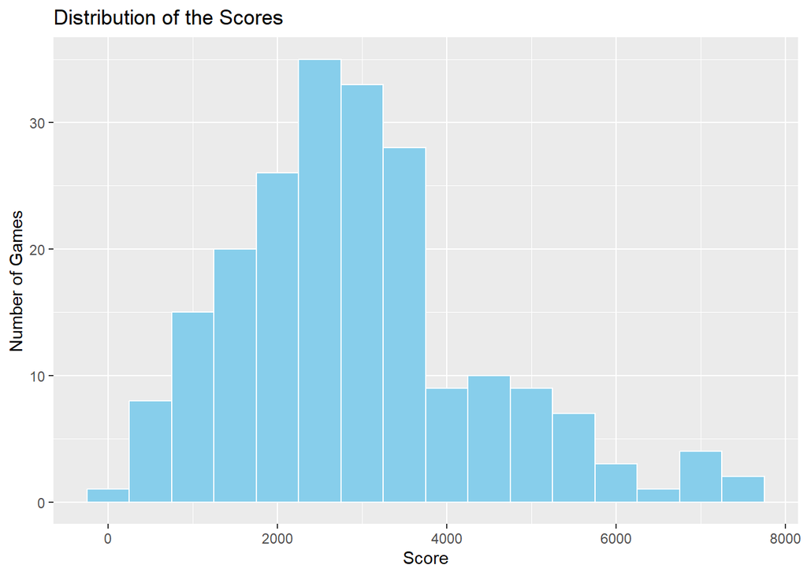

```r
cod %>% ggplot(
  mapping = aes(x = Score)) +
  geom_histogram(
    binwidth = 500,
    color = "White",
    fill = "skyblue") +
  labs(
    x = "Score",
    y = "Number of Games",
    title = "Distribution of the Scores"
  )
```

### Variable 2 - GameType

For the second variable, let’s look at the categorical variable GameType. This refers to the type/mode that was played in each game. First, let’s look to see if there is any missing data.

```r
cod %>% summarize(
  "NA count" = sum(is.na(GameType))
  )
```

```
## # A tibble: 1 × 1
##   `NA count`
##        <int>
## 1          0
```

There are no null values, so let’s continue to some summary statistics and a visualization.

```r
cod %>% group_by(
  GameType
  ) %>%
  summarize(
    Proportion = n()/nrow(cod)
    ) %>% arrange(
    desc(Proportion)
  ) %>% kable(
    caption = "Frequency Proportions for Game Type",
    digits = 2,
    col.names = c("Game Type", "Proportion")
  ) %>% kable_styling(
    bootstrap_options = c("striped", "condensed"),
    full_width = FALSE,
    position = "center"
  )
```

Frequency Proportions for Game Type

| Game Type | Proportion |
| --- | --- |
| HC - TDM | 0.93 |
| HC - Hardpoint | 0.04 |
| HC - Domination | 0.01 |
| HC - Kill Confirmed | 0.01 |

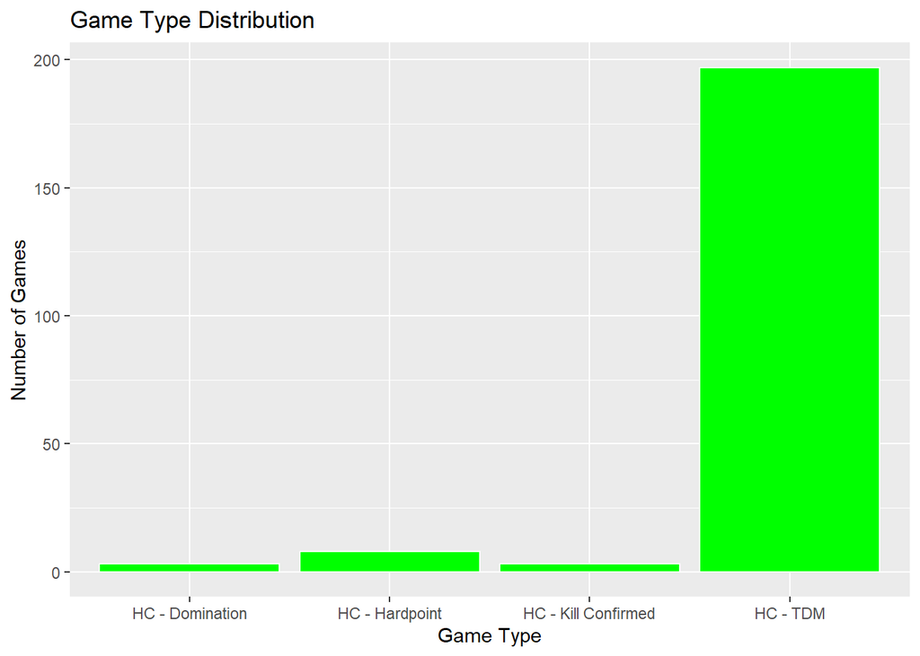

```r
cod %>% ggplot(
  mapping = aes(x = GameType)
) +
  geom_bar(
    color = "White",
    fill = "green") +
  labs(
    x = "Game Type",
    y = "Number of Games",
    title = "Game Type Distribution"
  )
```

From the summary statistics and the visualization, we can see that the player used that were four different types of modes that were played in this data set. The most commonly played mode was TDM, Team Deathmatch. In total, about 93% of the games were TDM while the remaining 7% were split among the modes, Domination, Hardpoint, and Kill Confirmed. Domination and Kill Confirmed sat at just 1% each. In conclusion, this explains that TDM is a much more favored game mode for this player with Hardpoint sitting in second.

### Variable 3 - Choice

For the third variable, let’s look at the categorical variable Choice. This refers to the map of each game. First, let’s look to see if there is any missing data.

```r
cod %>% summarize(
  "NA count" = sum(is.na(Choice))
  )
```

```
## # A tibble: 1 × 1
##   `NA count`
##        <int>
## 1          1
```

There is 1 NA value. So, let’s filter that out before we move on to the summary statistics and visualization.

```r
cod2 <- #Filters out the NA value
  cod %>%
  filter(!is.na(Choice)) #From 211 obs. to 210
```

```r
cod2 %>% group_by(
  Choice
  ) %>%
  summarize(
    Proportion = n()/nrow(cod2)
  ) %>% arrange(
    desc(Proportion)
  ) %>% kable(
    caption = "Frequency Proportions for Choice",
    digits = 2,
    col.names = c("Choice", "Proportion")
  ) %>% kable_styling(
    bootstrap_options = c("striped", "condensed"),
    full_width = FALSE,
    position = "center"
  )
```

Frequency Proportions for Choice

| Choice | Proportion |
| --- | --- |
| Crossroads Strike | 0.07 |
| Diesel | 0.07 |
| Rush | 0.07 |
| Collateral Strike | 0.06 |
| Raid | 0.06 |
| Standoff | 0.06 |
| Drive-In | 0.05 |
| Zoo | 0.05 |
| Nuketown ’84 | 0.04 |
| Slums | 0.04 |
| Yamantau | 0.04 |
| Garrison | 0.04 |
| Apocalypse | 0.03 |
| Cartel | 0.03 |
| Checkmate | 0.03 |
| Express | 0.03 |
| Hijacked | 0.03 |
| Miami Strike | 0.03 |
| WMD | 0.03 |
| Deprogram | 0.02 |
| Moscow | 0.02 |
| The Pines | 0.02 |
| Echelon | 0.02 |
| Jungle | 0.02 |
| Amerika | 0.01 |

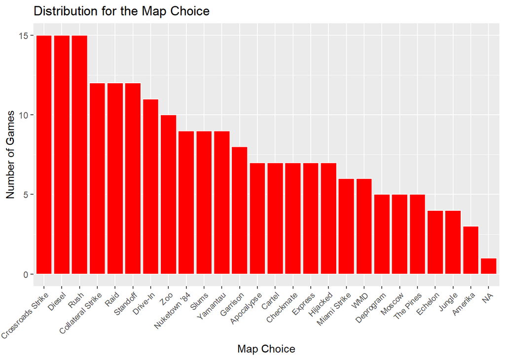

```r
cod %>% arrange(
  desc(Choice)
  ) %>% ggplot(
  mapping = aes(x = fct_infreq(Choice, ordered = TRUE))
) +
  geom_bar(
    color = "White",
    fill = "red") +
  labs(
    x = "Map Choice",
    y = "Number of Games",
    title = "Distribution for the Map Choice"
  ) +
  theme(axis.text.x = element_text(angle = 45, hjust = 1, size = 8)) #Researched to shrink text size
```

From the summary statistics and the visualization, we can see that the Choice of maps played included a wide variety. The top three most common maps played were Crossroads Strike, Diesel, and Rush. Those three maps stood at 7% while the next highest was 6%. All the percentages were pretty close together. From the visualization you can clearly see how many games were played with each of the maps. For example, the top three maps were played 15 times from this data set. The least played map was Amerika, which was played just 3 times.

## Task 3 - Exploring Relationships between Variables

In this task, we will take two variables from the data set and explore the relationship between the two. We will choose the variables Eliminations and Deaths. Both of these variables are quantitative. We are going to make individual summary statistics and then make a combined statistic.

```r
cod %>% summarize(
  min = min(Eliminations),
  first_quartile = quantile(Eliminations, .25),
  median = median(Eliminations),
  third_quartile = quantile(Eliminations, .75),
  max = max(Eliminations),
  sd = sd(Eliminations)
  ) %>% kable(
    caption = "Summary Statistics for Eliminations",
    digits = 2,
    col.names = c("Min", "1st Quartile", "Median", "3rd Quartile", "Max", "Standard Deviation"),
    align = "c"
  ) %>% kable_styling(
    bootstrap_options = c("striped", "condensed"),
    full_width = FALSE,
    position = "center"
  )
```

Summary Statistics for Eliminations

| Min | 1st Quartile | Median | 3rd Quartile | Max | Standard Deviation |
| --- | --- | --- | --- | --- | --- |
| 2 | 11 | 14 | 18.5 | 39 | 6.13 |

```r
cod %>% summarize(
  min = min(Deaths),
  first_quartile = quantile(Deaths, .25),
  median = median(Deaths),
  third_quartile = quantile(Deaths, .75),
  max = max(Deaths),
  sd = sd(Deaths)
  ) %>% kable(
    caption = "Summary Statistics for Deaths",
    digits = 2,
    col.names = c("Min", "1st Quartile", "Median", "3rd Quartile", "Max", "Standard Deviation"),
    align = "c"
  ) %>% kable_styling(
    bootstrap_options = c("striped", "condensed"),
    full_width = FALSE,
    position = "center"
  )
```

Summary Statistics for Deaths

| Min | 1st Quartile | Median | 3rd Quartile | Max | Standard Deviation |
| --- | --- | --- | --- | --- | --- |
| 4 | 12 | 15 | 17.5 | 42 | 5.13 |

```r
cod %>%  #The most common relationship in video games, Kill-Death Ratio (kdr)
  summarize(
    kdr = mean(Eliminations / Deaths, na.rm = TRUE)
  )
```

```
## # A tibble: 1 × 1
##     kdr
##   <dbl>
## 1  1.11
```

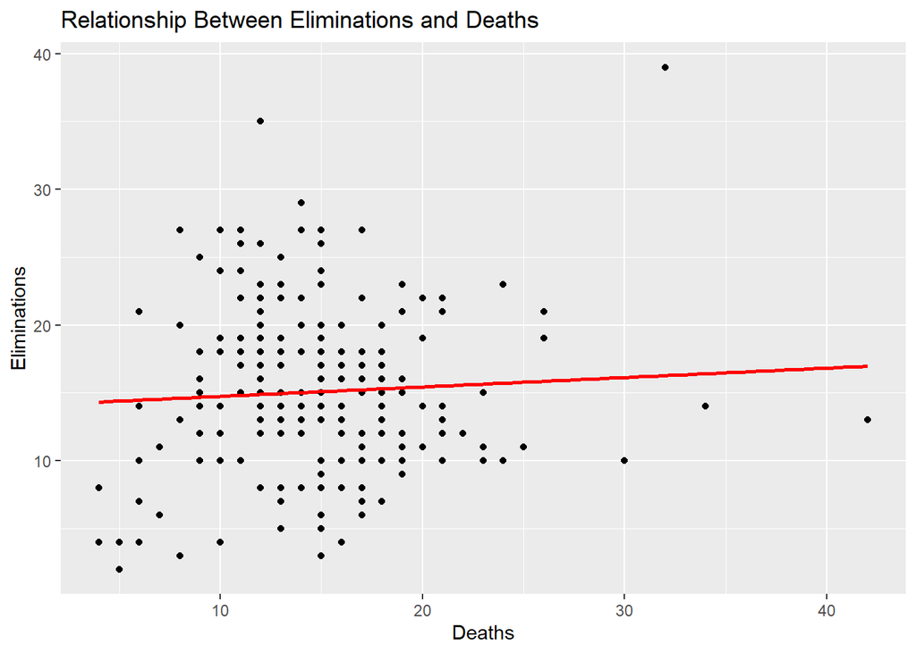

```r
cod %>%
  ggplot(aes(x = Deaths, y = Eliminations)) +
  geom_point(color = "black") +
  geom_smooth(method = "lm", se = FALSE, color = "red") +
  labs(
    x = "Deaths",
    y = "Eliminations",
    title = "Relationship Between Eliminations and Deaths"
  )
```

```r
model_lm <- lm(Eliminations ~ Deaths, data = cod)
summary(model_lm)
```

```
##
## Call:
## lm(formula = Eliminations ~ Deaths, data = cod)
##
## Residuals:
##      Min       1Q   Median       3Q      Max
## -12.3995  -4.2994  -0.6763   3.2890  22.7315
##
## Coefficients:
##             Estimate Std. Error t value Pr(>|t|)
## (Intercept) 14.05334    1.30681  10.754   <2e-16 ***
## Deaths       0.06922    0.08257   0.838    0.403
## ---
## Signif. codes:  0 '***' 0.001 '**' 0.01 '*' 0.05 '.' 0.1 ' ' 1
##
## Residual standard error: 6.138 on 209 degrees of freedom
## Multiple R-squared:  0.003351,   Adjusted R-squared:  -0.001417
## F-statistic: 0.7028 on 1 and 209 DF,  p-value: 0.4028
```

From the summary statistics and the visualization, we can see that the relationship between eliminations and deaths is slightly positive. From the linear model, we can conclude that for each additional death, the average change in eliminations is an increase in .06922. From the scatterplot, we can see that there is a weak positive relationship between the two. The points are widely scattered. This weak positive relationship can be summarized by the Multiple R-squared value of .003351. This means that only .003351 of total variation in eliminations can be explained by deaths. This is a very weak relationship.

While providing individual summary statistics for both variables, we also created a new summary statistic by using the mean value and dividing the two variables. We created a variable called kdr, better known as kill-death ratio. The kdr for each game is calculated by dividing eliminations and deaths. To find the ultimate kdr of this data set, we took the mean value and arrived at approximately 1.11. This means that, on average, the player had 1.11 eliminations for every death during their games.

## Task 4 - Calculating proportion of game outcomes (win, loss, draw)

```r
cod <- cod %>%
  separate(Result, into = c("player_score", "other_score"), sep = "-", convert = TRUE) %>%
  mutate(
    Win = ifelse(player_score > other_score, 1, 0),
    Loss = ifelse(player_score < other_score, 1, 0),
    Draw = ifelse(player_score == other_score, 1, 0)
  )

cod %>%
  summarise(
    win_proportion = mean(Win),
    loss_proportion = mean(Loss),
    draw_proportion = mean(Draw)
  )
```

```
## # A tibble: 1 × 3
##   win_proportion loss_proportion draw_proportion
##            <dbl>           <dbl>           <dbl>
## 1          0.540           0.445          0.0142
```

From the above statistics, the player in the dataset won approximately 54% of their games, lost approximately 45%, and drew approximately 1%.

## Task 5 - Answering an inference question with logistic regression

### How does a player’s eliminations and deaths explain whether the player won the game?

```r
cod <- cod %>%
  select(Win, Eliminations, Deaths) %>%
  na.omit()

model <- glm(Win ~ Eliminations + Deaths, family = binomial, data = cod)

summary(model)
```

```
##
## Call:
## glm(formula = Win ~ Eliminations + Deaths, family = binomial,
##     data = cod)
##
## Coefficients:
##              Estimate Std. Error z value Pr(>|z|)
## (Intercept)   0.61065    0.56663   1.078  0.28117
## Eliminations  0.07082    0.02470   2.867  0.00414 **
## Deaths       -0.10076    0.03120  -3.229  0.00124 **
## ---
## Signif. codes:  0 '***' 0.001 '**' 0.01 '*' 0.05 '.' 0.1 ' ' 1
##
## (Dispersion parameter for binomial family taken to be 1)
##
##     Null deviance: 291.14  on 210  degrees of freedom
## Residual deviance: 272.18  on 208  degrees of freedom
## AIC: 278.18
##
## Number of Fisher Scoring iterations: 4
```

The estimated logit equation is given by:

$$log(\frac{\hat{p}_i}{1-\hat{p}_i})=.61065 +
0.07082x_{i,eliminations} - 0.10076x_{i,deaths}$$

```r
exp(.07082)
```

```
## [1] 1.073388
```

```r
exp(-.10076)
```

```
## [1] 0.90415
```

While controlling for the number of deaths, for each additional elimination the player gets, we expect the odds of the player winning to increase by 7.34%, on average.

While controlling for the number of eliminations, for each additional death the player has, we expect the odds of the player winning to decrease by 9.59%, on average.

Let’s look at the 95% confidence intervals to make sure that 0 isn’t a plausible value for either of the coefficients.

```r
confint(model)
```

```
##                    2.5 %      97.5 %
## (Intercept)  -0.49316318  1.74714343
## Eliminations  0.02337517  0.12065585
## Deaths       -0.16438770 -0.04177223
```

0 is not in the range of plausible values, determined by the 95% confidence intervals, for either coefficient. This suggests that both effects are statistically significant at the alpha = .05 level.

Overall, these results indicate that a player’s performance, in terms of eliminations and deaths, is associated with their likelihood of winning: higher eliminations are associated with higher odds of winning, while higher deaths are associated with lower odds of winning.